# Querying MIMIC-III – Tutorial Problem – Tidyverse/dplyr

efg | 2018-09-21 | Updated 2018-12-31.

# Overview

The purpose of this script is to reproduce the “Tutorial Problem” from [Querying MIMIC-III](https://mimic.physionet.org/tutorials/intro-to-mimic-iii/), Section 8, using Tidyverse/dplyr in the examples instead of SQL used in the original solution. This enables a direct comparison between solving the problem using SQL and dplyr/dbplyr.

The examples from Section 3 “Patient numbers” through Section 7 “Services are in a separate notebook.

Many of the comments below are from the source above.

Prerequisites: This tutorial assumes that you have an active connection to an instance of MIMIC-III running on PostgreSQL. Note also that all the queries are written assuming that the MIMIC-III database is on your default search path.

NOTES:

- RPostgreSQL works fine with dates before 1970, but seems to truncate datetime timestamps to dates in RStudio, and does not compute time intervals correctly at times.
- Rpostgres does NOT work with dates before 1970 (*fix expected in Feb. 2019*), but is needed for Step 7 here for results to match between SQL and dplyr solutions.

# Setup

Packages

```r
library(DBI)
library(RPostgreSQL)
library(RPostgres)
library(tidyverse)
library(dbplyr,    warn.conflicts=FALSE)
library(lubridate, warn.conflicts=FALSE)   # date computations
library(kableExtra)
```

Helper function: Common formatting mostly for data.frames/tibbles below

```r
Show <- function(data, caption = NULL)
{
  data                               %>%
  kable("html", caption = caption)   %>%
  kable_styling(bootstrap_options = c("striped", "bordered", "condensed"),
                position = "left", full_width = FALSE, font_size=12)
}
```

Open database

```r
MimicDB <- dbConnect(RPostgreSQL::PostgreSQL(),    # PostgreSQL for Steps 1 - 6
                     dbname   = "mimic",
                     user     = Sys.getenv("MIMIC_User"),
                     password = Sys.getenv("MIMIC_Password"),
                     options  = "-c search_path=mimiciii")

MimicVersion <- "MIMIC-III, v1.4"
```

Table references

```r
icustays   <- tbl(MimicDB, in_schema("mimiciii", "icustays"))
patients   <- tbl(MimicDB, in_schema("mimiciii", "patients"))
admissions <- tbl(MimicDB, in_schema("mimiciii", "admissions"))
```

# Querying MIMIC-III

## 8. Tutorial problem

How would you gather useful information about patients admitted to the ICU? The problem can be broken down into several parts:

### Step 1

First start with retrieving `subject_id`, `hadm_id`, `icustay_id`, `intime`, and `outtime` from the `icustays` table.

```r
results1 <-
  icustays                                                  %>%
  select(subject_id, hadm_id, icustay_id, intime, outtime)  %>%
  collect()    # force execution by DB server and return as R object
```

All results returned to in-memory tibble

```r
dim(results1)
```

```
[1] 61532     5
```

```r
results1 %>%
  head() %>%
  Show("Selected fields from icustays")
```

Selected fields from icustays

| subject_id | hadm_id | icustay_id | intime | outtime |
| --- | --- | --- | --- | --- |
| 268 | 110404 | 280836 | 2198-02-14 | 2198-02-18 |
| 269 | 106296 | 206613 | 2170-11-05 | 2170-11-08 |
| 270 | 188028 | 220345 | 2128-06-24 | 2128-06-27 |
| 271 | 173727 | 249196 | 2120-08-07 | 2120-08-10 |
| 272 | 164716 | 210407 | 2186-12-25 | 2186-12-27 |
| 273 | 158689 | 241507 | 2141-04-19 | 2141-04-20 |

### Step 2

Using the patients table retrieve the calculated age of patients.

```r
results2 <-
  icustays                                                             %>%
  inner_join(patients, by="subject_id")                                %>%
  select(subject_id, hadm_id, icustay_id, intime, outtime, dob)        %>%
  collect()                                                            %>%
  mutate(ageYears = (as.numeric(floor_date(intime, unit="day") -
                                floor_date(dob,    unit="day"),
                                units="days")  /  365.242)  %>%  round(2))  %>%
  select(-dob)
```

```r
dim(results2)
```

```
[1] 61532     6
```

```r
results2   %>%
  head()   %>%
  Show(caption = "Calculated ages")
```

Calculated ages

| subject_id | hadm_id | icustay_id | intime | outtime | ageYears |
| --- | --- | --- | --- | --- | --- |
| 268 | 110404 | 280836 | 2198-02-14 | 2198-02-18 | 65.98 |
| 269 | 106296 | 206613 | 2170-11-05 | 2170-11-08 | 40.10 |
| 270 | 188028 | 220345 | 2128-06-24 | 2128-06-27 | 80.08 |
| 271 | 173727 | 249196 | 2120-08-07 | 2120-08-10 | 45.68 |
| 272 | 164716 | 210407 | 2186-12-25 | 2186-12-27 | 67.10 |
| 273 | 158689 | 241507 | 2141-04-19 | 2141-04-20 | 33.69 |

The following graphic is an addition to the original example.

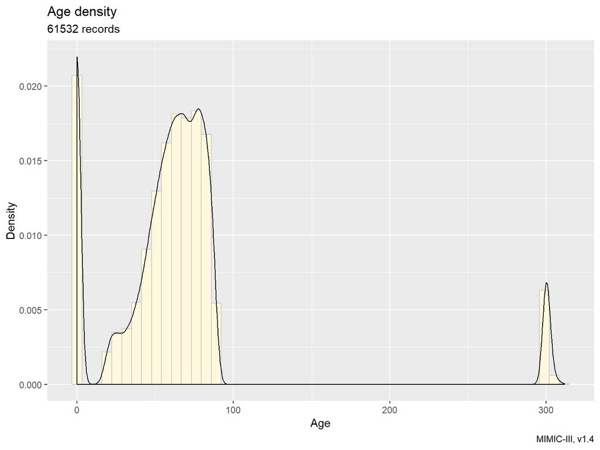

```r
ggplot(results2, aes(x=ageYears, y=..density..))            +
  geom_histogram(fill="cornsilk", color="grey80", bins=50)  +
  geom_density()                                            +
  labs(title    = "Age density",
       subtitle = paste0(nrow(results2), " records"),
       x = "Age",
       y = "Density",
       caption = MimicVersion)
```

Note the strange convention for ages > 89 to be represented as ~300 years.

### Step 3

Separate neonates from adult patients.

```r
results3 <-
  icustays                                                            %>%
  inner_join(patients, by="subject_id")                               %>%
  select(subject_id, hadm_id, icustay_id, intime, outtime, dob)       %>%
  collect()                                                           %>%
  mutate(ageYears = (as.numeric(floor_date(intime, unit="day") -
                                floor_date(dob,    unit="day"),
                                units="days")  /  365.242)  %>%  round(2)) %>%
  select(-dob)                                                        %>%
  mutate(icuStayAgeGroup =
           case_when(
             ageYears <=  1 ~ "neonate",
             ageYears <= 14 ~ "middle",
             ageYears > 100 ~ ">89",
             TRUE           ~ "adult"
           ))
```

```r
dim(results3)
```

```
[1] 61532     7
```

```r
results3 %>% head() %>% Show()
```

| subject_id | hadm_id | icustay_id | intime | outtime | ageYears | icuStayAgeGroup |
| --- | --- | --- | --- | --- | --- | --- |
| 268 | 110404 | 280836 | 2198-02-14 | 2198-02-18 | 65.98 | adult |
| 269 | 106296 | 206613 | 2170-11-05 | 2170-11-08 | 40.10 | adult |
| 270 | 188028 | 220345 | 2128-06-24 | 2128-06-27 | 80.08 | adult |
| 271 | 173727 | 249196 | 2120-08-07 | 2120-08-10 | 45.68 | adult |
| 272 | 164716 | 210407 | 2186-12-25 | 2186-12-27 | 67.10 | adult |
| 273 | 158689 | 241507 | 2141-04-19 | 2141-04-20 | 33.69 | adult |

```r
results3                    %>%
  group_by(icuStayAgeGroup) %>%
  count()                   %>%
  Show(caption = "Counts by Age Group")
```

Counts by Age Group

| icuStayAgeGroup | n |
| --- | --- |
| >89 | 2721 |
| adult | 50711 |
| neonate | 8100 |

### Step 4

By incorporating the admissions table, find how long each stay was BEFORE the patients were admitted to the ICU.

Changed original query to return preiculos (pre-ICU Length-of-Stay) in days instead of years.

```r
results4 <-
  icustays                                                            %>%
  inner_join(patients,   by = "subject_id")                           %>%
  inner_join(admissions, by = c("subject_id", "hadm_id"))             %>%
  select(subject_id, hadm_id, icustay_id, intime, outtime,
         dob, admittime)                                              %>%
  collect()                                                           %>%
  mutate(ageYears      = (as.numeric(floor_date(intime,    unit="day") -
                                     floor_date(dob,       unit="day"),
                                     units="days")  / 365.242)  %>%  round(2),

         preiculosDays = (as.numeric(floor_date(intime,    unit="day") -
                                     floor_date(admittime, unit="day"),
                                     units="days"))

        )                                                             %>%
  select(-dob, -admittime)                                            %>%
  mutate(icuStayAgeGroup =
           case_when
           (
             ageYears <=  1 ~ "neonate",
             ageYears <= 14 ~ "middle",
             ageYears > 100 ~ ">89",
             TRUE           ~ "adult"
           )
         )
```

```r
dim(results4)
```

```
[1] 61532     8
```

```r
results4 %>% head() %>% Show(caption = "Pre-ICU Length of Stay [days]")
```

Pre-ICU Length of Stay [days]

| subject_id | hadm_id | icustay_id | intime | outtime | ageYears | preiculosDays | icuStayAgeGroup |
| --- | --- | --- | --- | --- | --- | --- | --- |
| 268 | 110404 | 280836 | 2198-02-14 | 2198-02-18 | 65.98 | 3 | adult |
| 269 | 106296 | 206613 | 2170-11-05 | 2170-11-08 | 40.10 | 0 | adult |
| 270 | 188028 | 220345 | 2128-06-24 | 2128-06-27 | 80.08 | 1 | adult |
| 271 | 173727 | 249196 | 2120-08-07 | 2120-08-10 | 45.68 | 0 | adult |
| 272 | 164716 | 210407 | 2186-12-25 | 2186-12-27 | 67.10 | 0 | adult |
| 273 | 158689 | 241507 | 2141-04-19 | 2141-04-20 | 33.69 | 0 | adult |

```r
counts    <- table(results4$icuStayAgeGroup, useNA = "ifany")
facetName <- paste0(names(counts), " [", counts, "]")

variableLabeller <- function(variable,value)
{
  return(facetName[value])
}
```

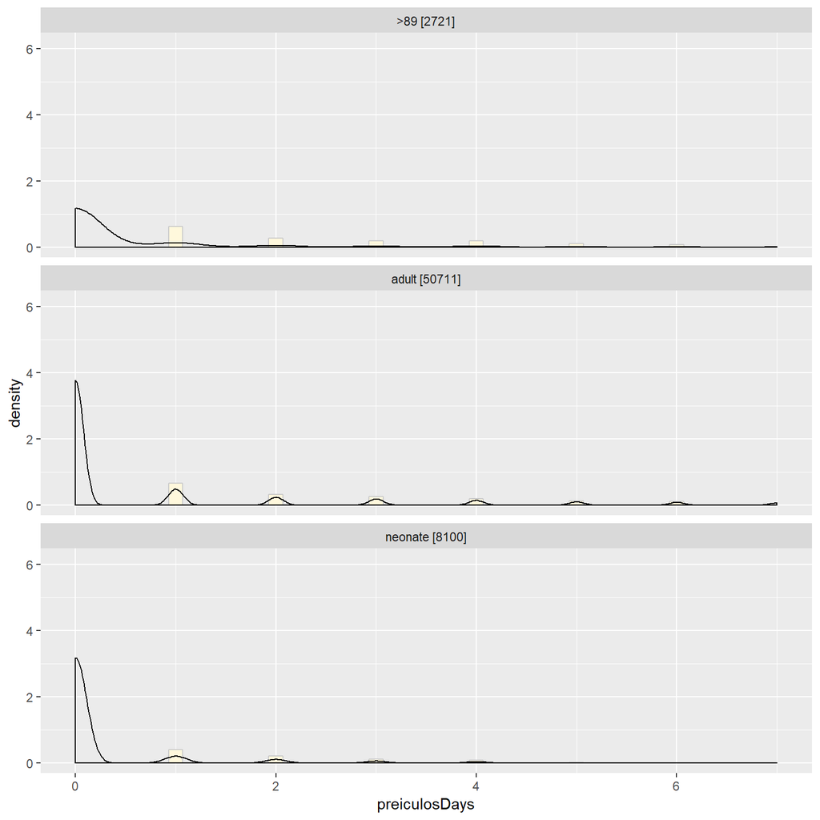

```r
ggplot(results4, aes(x = preiculosDays, y= ..density..))        +
  geom_histogram(fill = "cornsilk", color = "grey80", bins = 50)   +
  geom_density()                                                   +
  xlim(0, 7)                                                       +
  facet_wrap(~icuStayAgeGroup, nrow=length(counts),
             labeller = as_labeller(variableLabeller))
```

### Step 5

Next find the date of the patient’s death if applicable.

```r
results5 <-
  icustays                                                            %>%
  inner_join(patients,   by = "subject_id")                           %>%
  inner_join(admissions, by = c("subject_id", "hadm_id"))             %>%
  select(subject_id, hadm_id, icustay_id, intime, outtime,
         deathtime, dob, admittime)                                   %>%
  collect()                                                           %>%
  mutate(ageYears      = (as.numeric(floor_date(intime,    unit="day") -
                                     floor_date(dob,       unit="day"),
                                     units="days")  / 365.242)  %>%  round(2),

         preiculosDays = (as.numeric(floor_date(intime,    unit="day") -
                                     floor_date(admittime, unit="day"),
                                     units="days"))

        )                                                             %>%
  select(-dob, -admittime)                                            %>%
  mutate(icuStayAgeGroup =
           case_when
           (
             ageYears <=  1 ~ "neonate",
             ageYears <= 14 ~ "middle",
             ageYears > 100 ~ ">89",
             TRUE           ~ "adult"
           )
         )
```

```r
dim(results5)
```

```
[1] 61532     9
```

```r
results5 %>% head() %>% Show(caption = "Show Death Time (if applicable)")
```

Show Death Time (if applicable)

| subject_id | hadm_id | icustay_id | intime | outtime | deathtime | ageYears | preiculosDays | icuStayAgeGroup |
| --- | --- | --- | --- | --- | --- | --- | --- | --- |
| 268 | 110404 | 280836 | 2198-02-14 | 2198-02-18 | 2198-02-18 03:55:00 | 65.98 | 3 | adult |
| 269 | 106296 | 206613 | 2170-11-05 | 2170-11-08 | NA | 40.10 | 0 | adult |
| 270 | 188028 | 220345 | 2128-06-24 | 2128-06-27 | NA | 80.08 | 1 | adult |
| 271 | 173727 | 249196 | 2120-08-07 | 2120-08-10 | NA | 45.68 | 0 | adult |
| 272 | 164716 | 210407 | 2186-12-25 | 2186-12-27 | NA | 67.10 | 0 | adult |
| 273 | 158689 | 241507 | 2141-04-19 | 2141-04-20 | NA | 33.69 | 0 | adult |

```r
deaths <-
  results5                 %>%
  filter(!is.na(deathtime))
```

Counts of deaths

```r
deaths %>% count() %>% Show()
```

| n |
| --- |
| 6609 |

```r
deaths                                              %>%
  group_by(icuStayAgeGroup)                         %>%
  summarize(n = n(),
            minAge    = min(ageYears),
            Q25age    = quantile(ageYears, 0.25),
            medianAge = median(ageYears),
            meanAge   = round(mean(ageYears), 2),
            Q75age    = quantile(ageYears, 0.75),
            maxAge    = max(ageYears))             %>%
  Show(caption = "Stats by age group for patients who died")
```

Stats by age group for patients who died

| icuStayAgeGroup | n | minAge | Q25age | medianAge | meanAge | Q75age | maxAge |
| --- | --- | --- | --- | --- | --- | --- | --- |
| >89 | 590 | 300.00 | 300.00 | 300.0 | 300.42 | 300.0275 | 310.17 |
| adult | 5955 | 15.17 | 58.28 | 70.9 | 68.09 | 80.3300 | 88.99 |
| neonate | 64 | 0.00 | 0.00 | 0.0 | 0.00 | 0.0000 | 0.06 |

### Step 6

Then find those deaths that occurred while the patients were in the hospital.

```r
results6 <-
  icustays                                                                %>%
  inner_join(patients,   by = "subject_id")                               %>%
  inner_join(admissions, by = c("subject_id", "hadm_id"))                 %>%
  select(subject_id, hadm_id, icustay_id, intime, outtime,
         deathtime, dob, admittime, hospital_expire_flag)                 %>%
  collect()                                                               %>%
  mutate(ageYears      = (as.numeric(floor_date(intime,    unit="day") -
                                     floor_date(dob,       unit="day"),
                                     units="days")  / 365.242)  %>%  round(2),

         preiculosDays = (as.numeric(floor_date(intime,    unit="day") -
                                     floor_date(admittime, unit="day"),
                                     units="days")),
         icuStayAgeGroup =
           case_when
           (
             ageYears <=  1 ~ "neonate",
             ageYears <= 14 ~ "middle",
             ageYears > 100 ~ ">89",
             TRUE           ~ "adult"
           ),

         hospitalExpireFlag = ifelse(hospital_expire_flag == 1, "Y", "N")
        )                                                                %>%

  select(-dob, -admittime, -hospital_expire_flag)
```

```r
dim(results6)
```

```
[1] 61532    10
```

```r
results6 %>% head() %>% Show()
```

| subject_id | hadm_id | icustay_id | intime | outtime | deathtime | ageYears | preiculosDays | icuStayAgeGroup | hospitalExpireFlag |
| --- | --- | --- | --- | --- | --- | --- | --- | --- | --- |
| 268 | 110404 | 280836 | 2198-02-14 | 2198-02-18 | 2198-02-18 03:55:00 | 65.98 | 3 | adult | Y |
| 269 | 106296 | 206613 | 2170-11-05 | 2170-11-08 | NA | 40.10 | 0 | adult | N |
| 270 | 188028 | 220345 | 2128-06-24 | 2128-06-27 | NA | 80.08 | 1 | adult | N |
| 272 | 164716 | 210407 | 2186-12-25 | 2186-12-27 | NA | 67.10 | 0 | adult | N |
| 273 | 158689 | 241507 | 2141-04-19 | 2141-04-20 | NA | 33.69 | 0 | adult | N |
| 274 | 130546 | 254851 | 2114-06-28 | 2114-07-07 | NA | 66.11 | 0 | adult | N |

```r
results6                                             %>%
  group_by(icuStayAgeGroup, hospitalExpireFlag)      %>%
  count()                                            %>%
  spread(hospitalExpireFlag, n)                      %>%
  Show(caption = "Counts of Hospital Deaths ('Y')")
```

Counts of Hospital Deaths (‘Y’)

| icuStayAgeGroup | N | Y |
| --- | --- | --- |
| >89 | 2131 | 590 |
| adult | 44756 | 5955 |
| neonate | 8036 | 64 |

### Step 7

```r
dbDisconnect(MimicDB)
```

```
[1] TRUE
```

```r
MimicDB <- dbConnect(RPostgres::Postgres(),    # Postgres for Step 7
                     dbname   = "mimic",
                     user     = Sys.getenv("MIMIC_User"),
                     password = Sys.getenv("MIMIC_Password"),
                     bigint   = "integer",
                     options  = "-c search_path=mimiciii")
```

```r
icustays   <- tbl(MimicDB, in_schema("mimiciii", "icustays"))
patients   <- tbl(MimicDB, in_schema("mimiciii", "patients"))
admissions <- tbl(MimicDB, in_schema("mimiciii", "admissions"))
```

```r
results7 <-
  icustays                                                                %>%
  inner_join(patients,   by = "subject_id")                               %>%
  inner_join(admissions, by = c("subject_id", "hadm_id"))                 %>%
  select(subject_id, hadm_id, icustay_id, intime, outtime,
         deathtime, dob, admittime, hospital_expire_flag,
         dischtime, discharge_location)                                   %>%
  collect()                                                               %>%
  mutate(ageYears      = (as.numeric(floor_date(intime,    unit="day") -
                                     floor_date(dob,       unit="day"),
                                     units="days")  / 365.242)  %>%  round(2),

         preiculosDays = (as.numeric(floor_date(intime,    unit="day") -
                                     floor_date(admittime, unit="day"),
                                     units="days")),
         icuStayAgeGroup =
           case_when
           (
             ageYears <=  1 ~ "neonate",
             ageYears <= 14 ~ "middle",
             ageYears > 100 ~ ">89",
             TRUE           ~ "adult"
           ),

         hospitalExpireFlag = ifelse(hospital_expire_flag == 1, "Y", "N"),

         icuStayExpireFlag =
           case_when
           (
             (deathtime >= intime) &   # [don't use between](https://wiki.postgresql.org/wiki/Don%27t_Do_This)
             (deathtime <= outtime)                   ~ "Y",

             deathtime <= intime                      ~ "Y",

             (dischtime <= outtime) &
             (discharge_location == "DEAD/EXPIRED")   ~ "Y",

             TRUE                                     ~ "N"
           )
        )                                                                %>%

  select(-dob, -admittime, -hospital_expire_flag, -dischtime, -discharge_location) %>%
  arrange(subject_id, hadm_id)
```

```r
dim(results7)
```

```
[1] 61532    11
```

```r
results7 %>% head() %>% Show()
```

| subject_id | hadm_id | icustay_id | intime | outtime | deathtime | ageYears | preiculosDays | icuStayAgeGroup | hospitalExpireFlag | icuStayExpireFlag |
| --- | --- | --- | --- | --- | --- | --- | --- | --- | --- | --- |
| 2 | 163353 | 243653 | 2138-07-17 21:20:07 | 2138-07-17 23:32:21 | NA | 0.00 | 0 | neonate | N | N |
| 3 | 145834 | 211552 | 2101-10-20 19:10:11 | 2101-10-26 20:43:09 | NA | 76.52 | 0 | adult | N | N |
| 4 | 185777 | 294638 | 2191-03-16 00:29:31 | 2191-03-17 16:46:31 | NA | 47.84 | 0 | adult | N | N |
| 5 | 178980 | 214757 | 2103-02-02 06:04:24 | 2103-02-02 08:06:00 | NA | 0.00 | 0 | neonate | N | N |
| 6 | 107064 | 228232 | 2175-05-30 21:30:54 | 2175-06-03 13:39:54 | NA | 65.94 | 0 | adult | N | N |
| 7 | 118037 | 278444 | 2121-05-23 15:35:29 | 2121-05-23 22:01:00 | NA | 0.00 | 0 | neonate | N | N |

```r
table(results7$icuStayExpireFlag)
```

```
##
##     N     Y
## 56911  4621
```

```r
results7                                          %>%
  group_by(icuStayAgeGroup, icuStayExpireFlag)    %>%
  count()                                         %>%
  spread(icuStayExpireFlag, n)                    %>%
  Show(caption = "Counts of Deaths in ICU ('Y')")
```

Counts of Deaths in ICU (‘Y’)

| icuStayAgeGroup | N | Y |
| --- | --- | --- |
| >89 | 2338 | 383 |
| adult | 46537 | 4174 |
| neonate | 8036 | 64 |

```r
table(results7$hospitalExpireFlag, results7$icuStayExpireFlag)
```

```
        N     Y
  N 54923     0
  Y  1988  4621
```

# Close database

```r
dbDisconnect(MimicDB)
```

Processing time: 82.0 secs

2018-12-31 2155